# Desafio_Spike

Ledys Salazar

26-09-2020

# Contexto

El Sistema Electrico Nacional reúne a distintas empresas que en su conjunto se encargan de la generación, transmisión, distribución y consumo de energía en Chile. Para lograr esto, existen instalaciones que cumplen distintas funciones en el sistema, incluyendo:

- **Centrales eléctricas generadoras.**
- **Líneas de transmisión troncal.**
- **Líneas de subtransmisión y adicionales.**
- **Subestaciones eléctricas.**
- **Barras de consumo.**

El Coordinador Eléctrico Nacional es el organismo encargado de coordinar la operación de las instalaciones del Sistema Eléctrico Nacional, con el objetivo de garantizar la operación más económica del sistema, preservar su seguridad y garantizar el acceso abierto a los sistemas de transimisón. Dentro de sus funciones debe programar la generación de electricidad, con el objetivo de minimizar el costo marginal.

# Herramientas

# Input

Los input utilizados son:

- Retiros de energía [MWh] a nivel de barra y hora. demanda_real.csv

https://storage.googleapis.com/sistema_electrico_chile/demanda_real.csv

- Costos marginales reales [USD/MWh] a nivel de barra y hora (cada fila es una barra y día-hora). costo_marginal_real.csv

https://storage.googleapis.com/sistema_electrico_chile/costo_marginal_real.csv

- Costos marginales programados [USD/MWh] (por el SIC) a nivel de barra y hora (cada fila es una barra y día-hora). costo_marginal_programado.csv

https://storage.googleapis.com/sistema_electrico_chile/costo_marginal_programado.csv

- Base para entrenar modelos. base_para_predicción.csv

https://storage.googleapis.com/sistema_electrico_chile/base_para_prediccion.csv

# Preguntas

### **1. Costos marginales**

```
## Carga el archivo costo_marginal_real.csv. Estos son los costos marginales reales observados.
```

```
## [1] "4,309,951"
```

```
## [1] "1,192,124"
```

```
## Rows: 4,309,951
## Columns: 7
## $ barra_mnemotecnico            <chr> "BA01T005SE075T005", "BA01T005SE175T0...
## $ barra_referencia_mnemotecnico <chr> "BA02T002SE032T002", "BA02T002SE032T0...
## $ fecha                         <date> 2019-04-06, 2019-04-06, 2019-04-06, ...
## $ hora                          <dbl> 25, 25, 25, 25, 25, 25, 25, 25, 25, 2...
## $ costo_en_dolares              <dbl> 62.24, 62.56, 60.04, 61.65, 59.55, 59...
## $ costo_en_pesos                <dbl> 41.47176, 41.68498, 40.00585, 41.0786...
## $ nombre                        <chr> "BA S/E LORETO 15KV", "BA S/E RETIRO ...
```

```
## Rows: 1,192,124
## Columns: 5
## $ mnemotecnico_barra <chr> "BA01T002SE002T002", "BA01T002SE002T002", "BA01T...
## $ nombre_barra       <chr> "BA S/E ALTO JAHUEL 110KV SECCION 1", "BA S/E AL...
## $ fecha              <date> 2019-01-01, 2019-01-01, 2019-01-01, 2019-01-01,...
## $ hora               <dbl> 1, 2, 3, 4, 5, 6, 7, 8, 9, 10, 11, 12, 13, 14, 1...
## $ costo              <dbl> 49.89733, 50.47162, 50.07782, 49.79622, 49.79622...
```

```
## # A tibble: 0 x 7
## # Groups:   barra_mnemotecnico, barra_referencia_mnemotecnico, fecha, hora [0]
## # ... with 7 variables: barra_mnemotecnico <chr>,
## #   barra_referencia_mnemotecnico <chr>, fecha <date>, hora <dbl>,
## #   costo_en_dolares <dbl>, costo_en_pesos <dbl>, nombre <chr>
```

```
## # A tibble: 205,033 x 5
## # Groups:   mnemotecnico_barra, nombre_barra, fecha, hora [16,804]
##    mnemotecnico_barra nombre_barra fecha       hora costo
##    <chr>              <chr>        <date>     <dbl> <dbl>
##  1 -                  -            2019-01-01     1 134.
##  2 -                  -            2019-01-01     2 134.
##  3 -                  -            2019-01-01     3  56.2
##  4 -                  -            2019-01-01     4  57.4
##  5 -                  -            2019-01-01     5  56.1
##  6 -                  -            2019-01-01     6  57.4
##  7 -                  -            2019-01-01     7  57.4
##  8 -                  -            2019-01-01     8  63.5
##  9 -                  -            2019-01-01     9  54.3
## 10 -                  -            2019-01-01    10  50.9
## # ... with 205,023 more rows
```

```
##
##      17
## 4309951
```

```
## # A tibble: 239 x 2
##    nombre_barra                            n
##    <chr>                               <int>
##  1 -                                  180115
##  2 BA S/E 154KV B1                      3769
##  3 BA S/E A 100KV-BP1                   4345
##  4 BA S/E AGUA SANTA BARRA 110KV N° 1   4345
##  5 BA S/E AGUA SANTA BARRA 220KV N° 1   4345
##  6 BA S/E ALTO HOSPICIO 110KV           3769
##  7 BA S/E ALTO JAHUEL 110KV SECCION 1   4345
##  8 BA S/E ALTO JAHUEL 154KV             4345
##  9 BA S/E ALTO JAHUEL 220KV SECCION 1   4345
## 10 BA S/E ALTO JAHUEL 500KV SECCIÓN A   4345
## # ... with 229 more rows
```

```
## # A tibble: 239 x 2
##    mnemotecnico_barra      n
##    <chr>               <int>
##  1 -                  180115
##  2 BA01G004SE001T011    4345
##  3 BA01G004SE009G004    4345
##  4 BA01G004SE017G004    4345
##  5 BA01G004SE035G004    4345
##  6 BA01G004SE036G004    4345
##  7 BA01G006SE001G104    4345
##  8 BA01G006SE002G006    3769
##  9 BA01G010SE008G010    4345
## 10 BA01G021SE003G021    4345
## # ... with 229 more rows
```

```
##
##      1      2      3      4      5      6      7      8      9     10     11
## 179540 179540 179540 179540 179540 179540 179540 179540 179540 179540 179540
##     12     13     14     15     16     17     18     19     20     21     22
## 179540 179540 179540 179540 179540 179540 179540 179540 179540 179540 179540
##     23     24     25
## 179540 179540    991
```

```
##
##     1     2     3     4     5     6     7     8     9    10    11    12    13
## 49660 49660 49660 49660 49660 49660 49660 49660 49660 49660 49660 49660 49660
##    14    15    16    17    18    19    20    21    22    23    24    25
## 49660 49660 49660 49660 49660 49660 49660 49660 49660 49660 49660   284
```

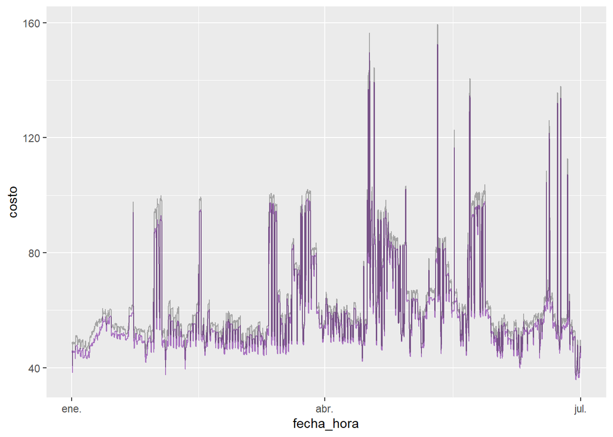

```
## [1] "barra_mnemotecnico"            "barra_referencia_mnemotecnico"
## [3] "fecha"                         "hora"
## [5] "costo_en_dolares"              "costo_en_pesos"
## [7] "nombre"                        "fecha_hora"
```

```
## [1] "mnemotecnico_barra" "nombre_barra"       "fecha"
## [4] "hora"               "costo"              "fecha_hora"
## [7] "MIN"                "MAX"
```

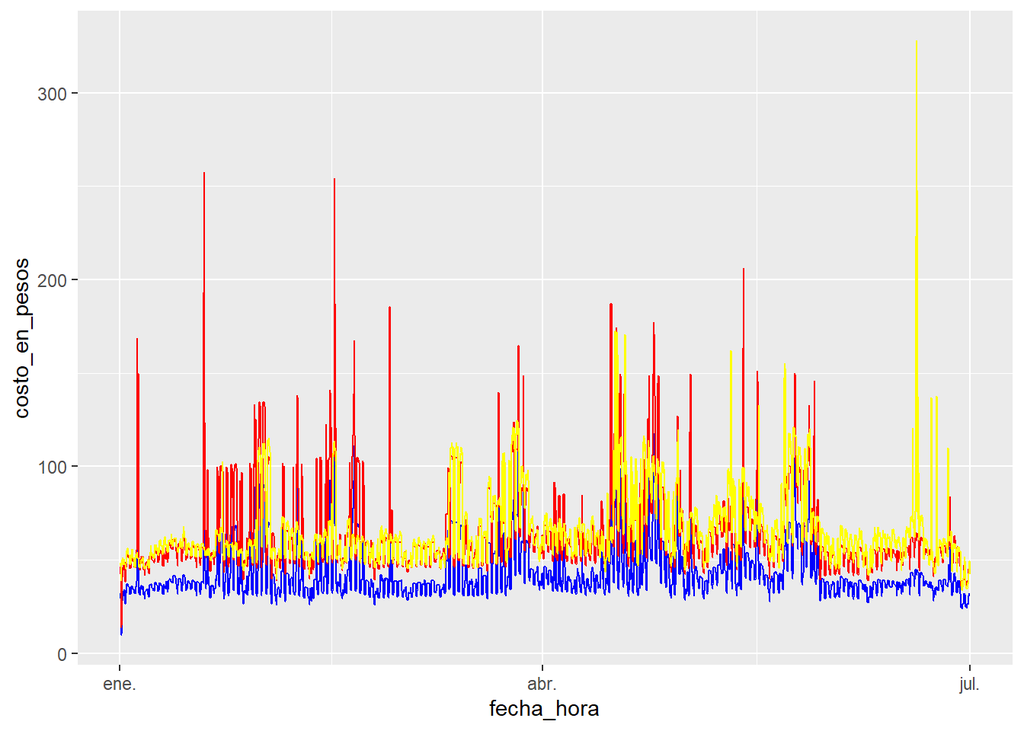

Analisis exploratorio

- ¿Qué puedes decir de las distintas variables?

```
## Rows: 4,321,416
## Columns: 11
## $ barra_mnemotecnico            <chr> "BA01T005SE075T005", "BA02T005SE081T0...
## $ barra_referencia_mnemotecnico <chr> "BA02T002SE032T002", "BA02T002SE032T0...
## $ fecha                         <date> 2019-01-24, 2019-01-24, 2019-01-24, ...
## $ hora                          <dbl> 1, 1, 1, 1, 1, 1, 1, 1, 1, 1, 1, 1, 1...
## $ costo_en_dolares              <dbl> 0.00, 62.72, 57.61, 58.40, 55.23, 54....
## $ costo_en_pesos                <dbl> 0.00000, 42.16415, 38.72890, 39.25998...
## $ nombre                        <chr> "BA S/E LORETO 15KV", "BA S/E PUNITAQ...
## $ fecha_hora                    <dttm> 2019-01-24 01:00:00, 2019-01-24 01:0...
## $ costo_programado              <dbl> NA, 61.69927, NA, NA, NA, NA, NA, 55....
## $ MIN                           <dbl> NA, 61.69927, NA, NA, NA, NA, NA, 55....
## $ MAX                           <dbl> NA, 61.69927, NA, NA, NA, NA, NA, 55....
```

- ¿Cómo distribuyen?

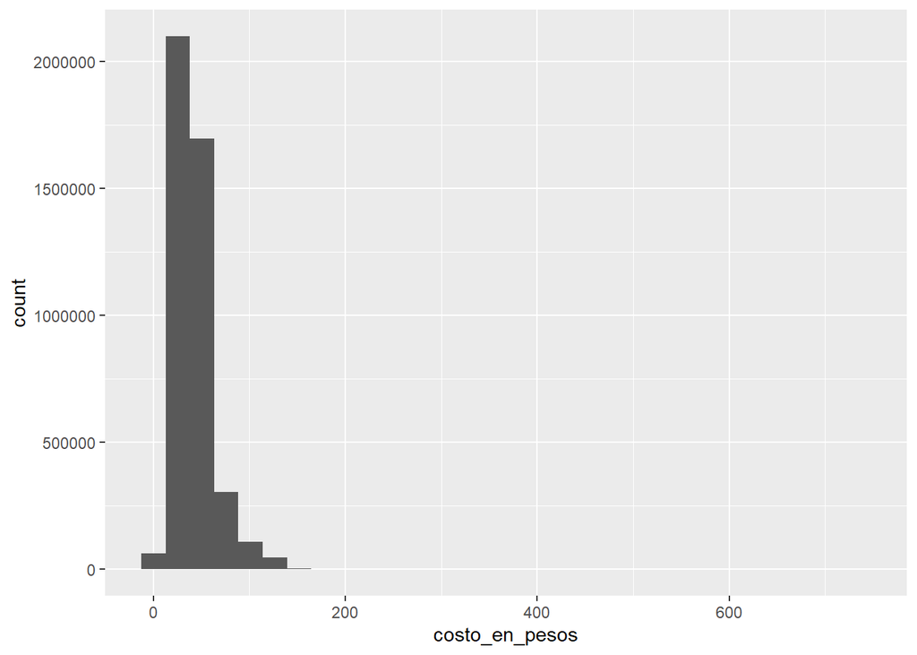

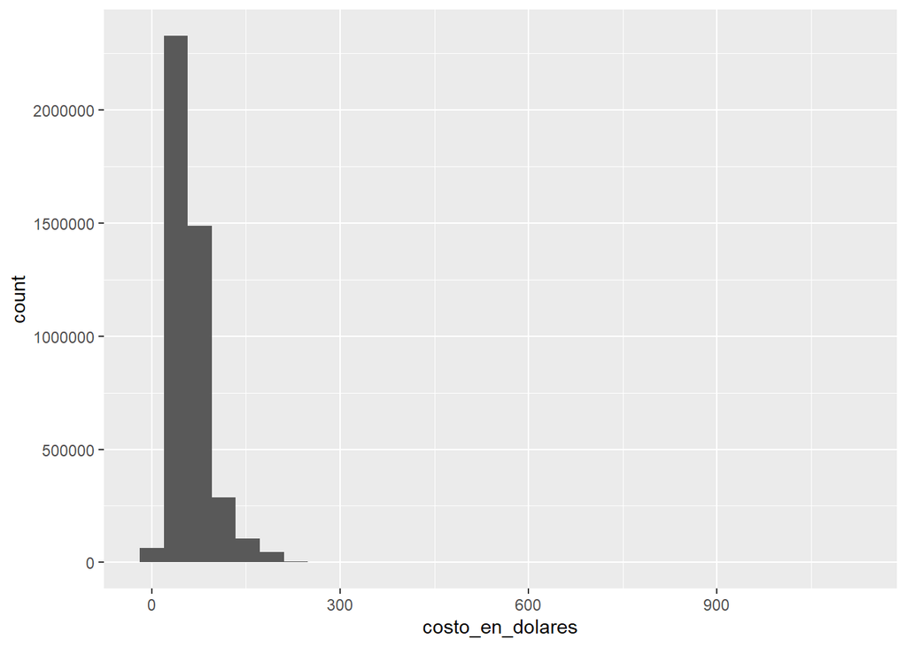

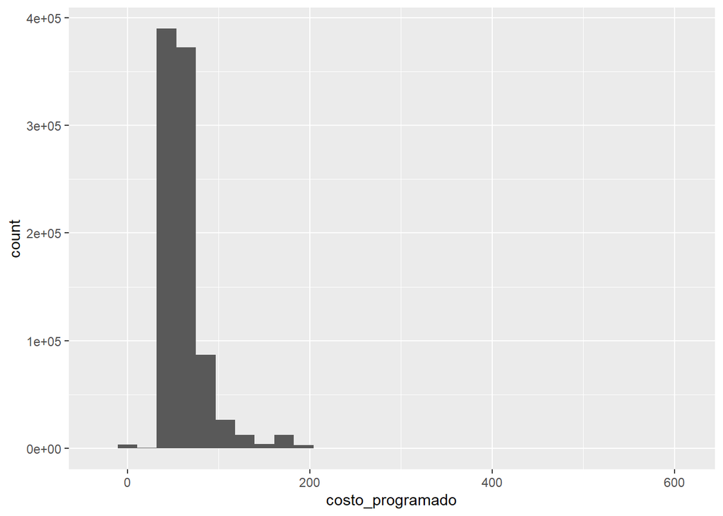

- ¿Para cuántas barras se programa el costo?

```
## [1] 220
```

- ¿Qué porcentaje es del total de barras que puedes observar en la base?

```
## [1] "22%"
```

### **2. Construcción de variables**

```
## Rows: 4,321,416
## Columns: 3
## $ desviacion     <dbl> NA, 1.02072806, NA, NA, NA, NA, NA, -0.58375786, NA,...
## $ desviacion_pct <dbl> NA, 0.016274363, NA, NA, NA, NA, NA, -0.010646687, N...
## $ desviacion_cat <dbl> 0, 0, 0, 0, 0, 0, 0, 0, 0, 0, 0, 0, 0, 0, 0, 0, 0, 0...
```

Describe la variable desviacion_cat . Qué puedes observar? Cambia a través del tiempo?

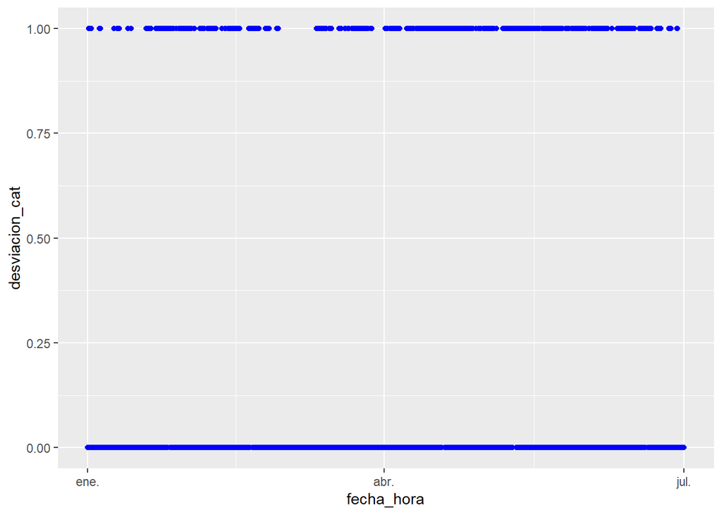

Se puede observar que cambia en el tiempo.

## 3. Visualización de datos

Crea la siguiente función: def time_plot_costo_barra(codigo_barra, fecha_inicial, fecha_final)

que tome como input el código de una barra y haga un plot en el tiempo del costo marginal real y del costo marginal programado. El eje x debe ser el tiempo. fecha_inicial y fecha_final_ dan los límites de este plot. Úsa esta función para plotear algunas barras. Acá hay un ejemplo:

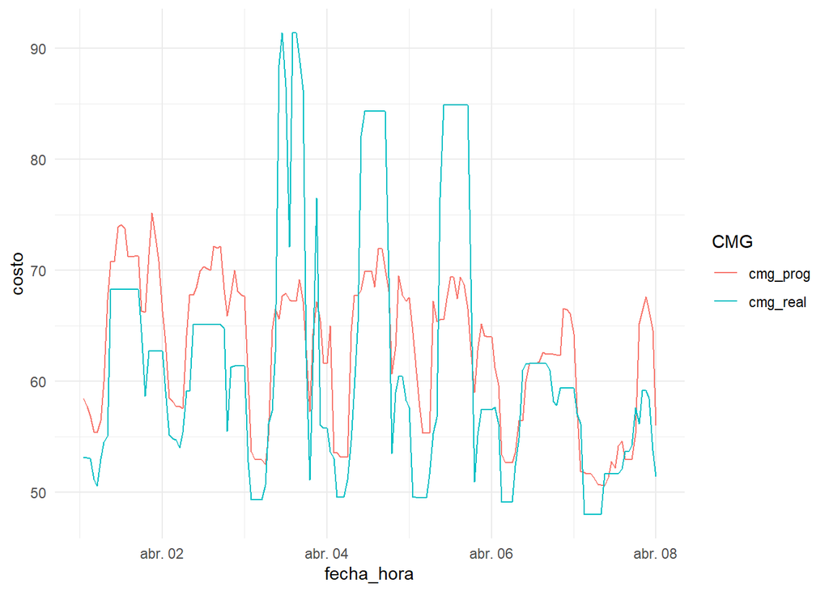

```
##  [1] "barra_mnemotecnico"            "barra_referencia_mnemotecnico"
##  [3] "fecha"                         "hora"
##  [5] "costo_en_dolares"              "costo_en_pesos"
##  [7] "nombre"                        "fecha_hora"
##  [9] "costo_programado"              "MIN"
## [11] "MAX"                           "desviacion"
## [13] "desviacion_pct"                "desviacion_cat"
```

```
## # A tibble: 5 x 5
## # Groups:   barra_mnemotecnico, barra_referencia_mnemotecnico [5]
##   barra_mnemotecnico barra_referencia_mnemo~ nombre           sum_cmg_real     n
##   <chr>              <chr>                   <chr>                   <dbl> <int>
## 1 BA01G049SE001G049  BA02T002SE032T002       BA S/E NUEVA VE~            0  4344
## 2 BA01L038SE001L038  BA02T002SE032T002       BA S/E PETRODOW~            0  4344
## 3 BA02T003SE009T003  BA02T002SE032T002       BA S/E BARRO BL~            0  4344
## 4 BA02T005SE046T005  BA02T002SE032T002       BA S/E LINARES ~            0  4344
## 5 BA02T005SE082T005  BA02T002SE032T002       BA S/E MONTE PA~            0  4344
```

```
## [1] -21720
```

# 4. Base para los modelos

Carga la base base_para_predicción.csv. Esta será la base principal para las siguientes preguntas.

En rasgos generales, ¿Qué puedes decir de los datos? (dimensiones, tipo de datos, variables categóricas, variables numéricas, fechas). A partir de la variable fecha, crea nuevas variables para el año, mes, semana del año, dia del calendario, dia de la semana y una variable que indique si el dia corresponde a un día de semana o fin de semana. Estas features/variables te servirán para entrenar el modelo. Implementa una función que para una subestación y una variable, grafique múltiples series de tiempo diarias correspondientes a una lista de fechas. Para esto, la función debe recibir como argumentos: código de una subestación, una variable (serie numérica), y una lista de fechas (año-mes-día). Por ejemplo: para la subestación SE005T002 y la variable gen_solar_total_mwh, la función debe graficar los perfiles diarios de generación solar por hora para las fechas ‘2019-01-10’, ‘2019-02-10’ y ‘2019-03-10’. Grafica la curva de generación solar, por hora, en la subestación SE005T002 para las fechas del 10, 11, 12, 13 y 14 de enero de 2019. Haz lo mismo para la subestación SE127T005. Que podrías decir, en términos generales, sobre la generación solar y las dos subestaciones mencionadas, basados en estos dos gráficos? Grafica la curva de generación térmica, por hora, en la subestación SE020G213 para los días 14, 15, 16 y 17 de mayo de 2019. Haz lo mismo para la subestación SE106G216. Que podrías decir, en términos generales, sobre la generación térmica en esta subestación con respecto a este gráfico?

```
## Rows: 112,779
## Columns: 15
## $ nemotecnico_se           <chr> "SE031G216", "SE031G216", "SE031G216", "SE...
## $ fecha                    <chr> "2019-01-04 00:00:00 UTC", "2019-01-04 00:...
## $ hora                     <dbl> 1, 2, 3, 4, 5, 6, 7, 8, 9, 10, 11, 12, 13,...
## $ gen_eolica_total_mwh     <chr> NA, NA, NA, NA, NA, NA, NA, NA, NA, NA, NA...
## $ gen_geotermica_total_mwh <chr> NA, NA, NA, NA, NA, NA, NA, NA, NA, NA, NA...
## $ gen_hidraulica_total_mwh <chr> NA, NA, NA, NA, NA, NA, NA, NA, NA, NA, NA...
## $ gen_solar_total_mwh      <dbl> NA, NA, NA, NA, NA, NA, NA, NA, NA, NA, NA...
## $ gen_termica_total_mwh    <dbl> 0.0, 0.0, 0.0, 0.0, 0.0, 0.0, 0.0, 0.0, 0....
## $ cmg_real                 <dbl> 56.20, 56.20, 56.20, 56.20, 56.20, 56.20, ...
## $ cmg_prog                 <dbl> 55.627852, 55.376645, 59.531891, 174.37892...
## $ cmg_desv                 <dbl> 0.57, 0.82, -3.33, -118.18, -116.62, -116....
## $ cmg_desv_pct             <dbl> 1.02, 1.48, -5.59, -67.77, -67.48, -67.48,...
## $ n_barras                 <dbl> 2, 2, 2, 2, 2, 2, 2, 2, 2, 2, 2, 2, 2, 2, ...
## $ demanda_mwh              <dbl> 1210767, 113232, 1089415, 1096867, 1071851...
## $ cap_inst_mw              <dbl> 13.20785, 13.20785, 13.20785, 13.20785, 13...
```

```
##
##   TRUE
## 112779
```

```
##
##   TRUE
## 112779
```

```
##
## FALSE  TRUE
## 34184 78595
```

```
##
## FALSE  TRUE
## 41818 70961
```

```
##
## FALSE  TRUE
## 61863 50916
```

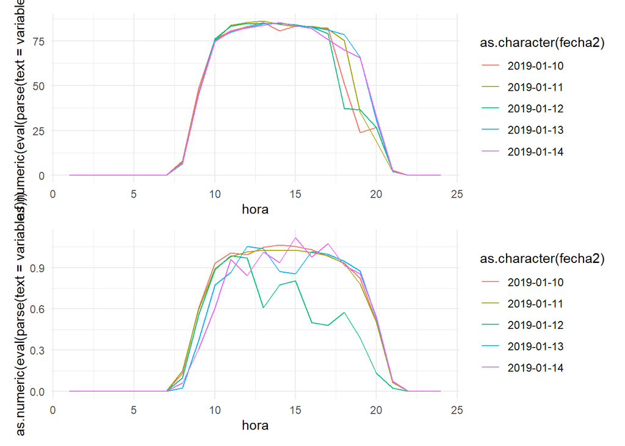

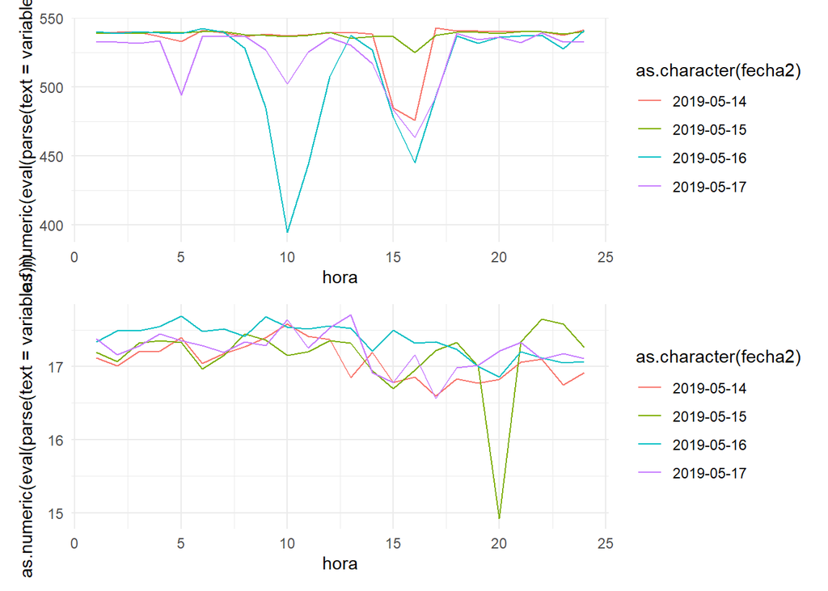

## 5. Predicción de desviaciones del costo marginal: modelo 1

Crea una variable target que sea igual a cero cuando la variable cmg_desv_pct esté en el rango [-15,15], e igual uno para cualquier otro caso. Hint: recuerda que existen valores infinitos. Ahora crea los siguientes features: en_total_mwh: suma de las cinco series de generación. lags y estadísticas acumuladas (por ejemplo: promedio, varianza) de las variables que consideres relevantes. Entrena un modelo que prediga si existirá una desviación en la hora siguiente. Adecúa la variable target para hacer esto posible. ¿Cómo le va a tu modelo? ¿En qué métricas te basas y por qué? ¿Cuales son las variables más importantes que considera este modelo?

```
## # A tibble: 112,779 x 2
##    target target2
##     <dbl>   <dbl>
##  1      0       0
##  2      0       0
##  3      0       1
##  4      1       1
##  5      1       1
##  6      1       1
##  7      1       1
##  8      1       0
##  9      0       0
## 10      0       0
## # ... with 112,769 more rows
```

```
## Rows: 112,779
## Columns: 27
## $ nemotecnico_se           <chr> "SE031G216", "SE031G216", "SE031G216", "SE...
## $ fecha                    <chr> "2019-01-04 00:00:00 UTC", "2019-01-04 00:...
## $ hora                     <dbl> 1, 2, 3, 4, 5, 6, 7, 8, 9, 10, 11, 12, 13,...
## $ gen_eolica_total_mwh     <dbl> NA, NA, NA, NA, NA, NA, NA, NA, NA, NA, NA...
## $ gen_geotermica_total_mwh <dbl> NA, NA, NA, NA, NA, NA, NA, NA, NA, NA, NA...
## $ gen_hidraulica_total_mwh <dbl> NA, NA, NA, NA, NA, NA, NA, NA, NA, NA, NA...
## $ gen_solar_total_mwh      <dbl> NA, NA, NA, NA, NA, NA, NA, NA, NA, NA, NA...
## $ gen_termica_total_mwh    <dbl> 0.0, 0.0, 0.0, 0.0, 0.0, 0.0, 0.0, 0.0, 0....
## $ cmg_real                 <dbl> 56.20, 56.20, 56.20, 56.20, 56.20, 56.20, ...
## $ cmg_prog                 <dbl> 55.627852, 55.376645, 59.531891, 174.37892...
## $ cmg_desv                 <dbl> 0.57, 0.82, -3.33, -118.18, -116.62, -116....
## $ cmg_desv_pct             <dbl> 1.02, 1.48, -5.59, -67.77, -67.48, -67.48,...
## $ n_barras                 <dbl> 2, 2, 2, 2, 2, 2, 2, 2, 2, 2, 2, 2, 2, 2, ...
## $ demanda_mwh              <dbl> 1210767, 113232, 1089415, 1096867, 1071851...
## $ cap_inst_mw              <dbl> 13.20785, 13.20785, 13.20785, 13.20785, 13...
## $ fecha2                   <date> 2019-01-04, 2019-01-04, 2019-01-04, 2019-...
## $ year                     <dbl> 2019, 2019, 2019, 2019, 2019, 2019, 2019, ...
## $ month                    <dbl> 1, 1, 1, 1, 1, 1, 1, 1, 1, 1, 1, 1, 1, 1, ...
## $ week                     <dbl> 1, 1, 1, 1, 1, 1, 1, 1, 1, 1, 1, 1, 1, 1, ...
## $ day                      <int> 4, 4, 4, 4, 4, 4, 4, 4, 4, 4, 4, 4, 4, 4, ...
## $ yday                     <dbl> 4, 4, 4, 4, 4, 4, 4, 4, 4, 4, 4, 4, 4, 4, ...
## $ wday                     <ord> viernes, viernes, viernes, viernes, vierne...
## $ wday2                    <dbl> 6, 6, 6, 6, 6, 6, 6, 6, 6, 6, 6, 6, 6, 6, ...
## $ fin_de_semana            <dbl> 0, 0, 0, 0, 0, 0, 0, 0, 0, 0, 0, 0, 0, 0, ...
## $ target                   <dbl> 0, 0, 0, 1, 1, 1, 1, 1, 0, 0, 0, 1, 1, 1, ...
## $ en_total_mwh             <dbl> 0.0, 0.0, 0.0, 0.0, 0.0, 0.0, 0.0, 0.0, 0....
## $ target2                  <dbl> 0, 0, 1, 1, 1, 1, 1, 0, 0, 0, 1, 1, 1, 1, ...
```

```
##
## Call:
## glm(formula = target2 ~ target + fin_de_semana + month + cap_inst_mw +
##     hora, family = binomial(), data = base_para_prediccion[[3]])
##
## Deviance Residuals:
##     Min       1Q   Median       3Q      Max
## -1.9490  -0.4511  -0.3881   0.5834   2.6109
##
## Coefficients:
##                 Estimate Std. Error z value Pr(>|z|)
## (Intercept)   -2.0619739  0.0295810  -69.71   <2e-16 ***
## target         3.4196864  0.0186440  183.42   <2e-16 ***
## fin_de_semana -0.3310573  0.0213766  -15.49   <2e-16 ***
## month         -0.1197433  0.0056957  -21.02   <2e-16 ***
## cap_inst_mw   -0.0006079  0.0000583  -10.43   <2e-16 ***
## hora           0.0208757  0.0013334   15.66   <2e-16 ***
## ---
## Signif. codes:  0 '***' 0.001 '**' 0.01 '*' 0.05 '.' 0.1 ' ' 1
##
## (Dispersion parameter for binomial family taken to be 1)
##
##     Null deviance: 127485  on 112777  degrees of freedom
## Residual deviance:  79398  on 112772  degrees of freedom
##   (1 observation deleted due to missingness)
## AIC: 79410
##
## Number of Fisher Scoring iterations: 5
```

```
## [1] 0.3772028
```